# NFW Distribution

Aaron Robotham

2018-05-28

## QDF Proof

This is a compact version of the paper [arXiv 1805.09550](https://arxiv.org/abs/1805.09550).

We define the un-normalised integral up to a normalised radius $q$ as

$$p'(q,c) = \ln(1 + c q)-\frac{c q}{1 + c q}.$$

We can define $p$, the correctly normalised probability (where $p(q=1,c)=1$ with a domain [0,1]) as

$$p(q,c) = \frac{p'(q,c)}{p'(1,c)} \Rightarrow p'(q,c)=p(q,c) p'(1,c)$$

Using the un-normalised variant $p'$ we can state that

$$p'+1 = \ln(1 + c q) - \frac{c q}{1 + c q} + \frac{1 + c q}{1 + c q} = \ln(1 + c q) + \frac{1}{1 + c q}.$$

Taking exponents and setting equal to $y$ we get

$$y = e^{p'+1} = (1 + c q) e^{1/(1 + c q)}.$$

We can the define $x$ such that

$$x = 1 + c q, \\
y = x e^{1/x}.$$

Here we can use the Lambert W function to solve for $x$, since it generically solves for relations like y = x e^{x} (where $x = W_0(y)$)). The exponent has a $1/x$ term, which modifies that solution to the slightly less elegant

$$x = -\frac{1}{W_0(-1/y)} = -\frac{1}{W_0(-1/e^{(p'+1)})}, \\
\text{sub for } q = \frac{x - 1}{c}, \\
q = -\frac{1}{c}\left(\frac{1}{W_0(-1/e^{(p'+1)})}+1\right).$$

Given the above, this opens up an analytic route for generating exact random samples of the NFW for any $c$ (where we must be careful to scale such that $p'(q,c)=p(q,c) p'(1,c)$) via,

$$r([0,1]; c) = q(p=U[0,1]; c).$$

## Some Example Usage

Both the PDF (**dnfw**) integrated up to x, and CDF at q (**pnfw**) should be the same (0.373, 0.562, 0.644, 0.712):

```r
for(con in c(1,5,10,20)){
  print(integrate(dnfw, lower=0, upper=0.5, con=con)$value)
  print(pnfw(0.5, con=con))
}
```

```
## [1] 0.373455
## [1] 0.373455
## [1] 0.5618349
## [1] 0.5618349
## [1] 0.6437556
## [1] 0.6437556
## [1] 0.7116174
## [1] 0.7116174
```

The **qnfw** should invert the **pnfw**, returning the input vector (1:9)/10:

```r
for(con in c(1,5,10,20)){
  print(qnfw(p=pnfw(q=(1:9)/10,con=con), con=con))
}
```

```
## [1] 0.1 0.2 0.3 0.4 0.5 0.6 0.7 0.8 0.9
## [1] 0.1 0.2 0.3 0.4 0.5 0.6 0.7 0.8 0.9
## [1] 0.1 0.2 0.3 0.4 0.5 0.6 0.7 0.8 0.9
## [1] 0.1 0.2 0.3 0.4 0.5 0.6 0.7 0.8 0.9
```

The sampling from **rnfw** should recreate the expected PDF from **dnfw**:

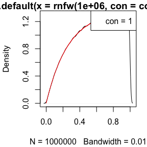

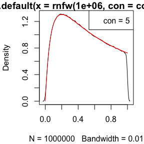

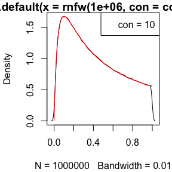

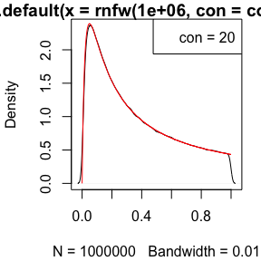

```r
for(con in c(1,5,10,20)){
  par(mar=c(4.1,4.1,1.1,1.1))
  plot(density(rnfw(1e6,con=con), bw=0.01))
  lines(seq(0,1,len=1e3), dnfw(seq(0,1,len=1e3),con=con),col='red')
  legend('topright',legend=paste('con =',con))
}
```

Happy sampling!